# quiz

jojoecp

5/126/2020

#Social Network Analysis: Twitter Network Quiz **NOTE:** Open in browser for the best experience

## Graph theory and SNA

This section will assess your understanding of Graph theory and SNA

1. Which statement is **TRUE** about graph theory & SNA: (a) Network can be divided into 2 types: directed and undirected. (b) SNA is basicly an implementation of graph theory in human social life. (c) In-degree in directed network, is a two-way relationship between nodes. usually drawn with lines without arrows. (d) Social Network Analysis can be implemented in wide areas, including finding information networks within terrorist group.
- (a), (b), and (c)
- (a), (b), and (d)
- (a), (c), and (d)
- all of the above
2. From the picture below. Calculate the *shortest path* between nodes 4 to nodes 13

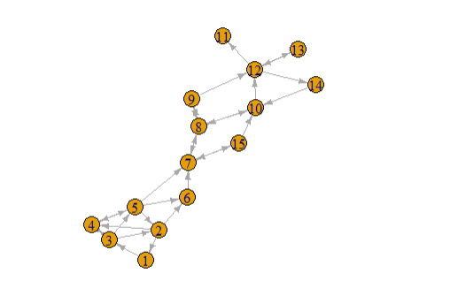

- 6
- 5
- 7
- 8

## SNA metrics (centrality & modularity)

3. Closeness centrality calculate shortest path from specific nodes to every nodes in the network. Thus the more central a node is, the closer it is to all other nodes. From the statements below, choose the **correct** intepretation of closeness centrality.
- nodes with high closeness centrality tend to be connected with similliar nodes that also have high closeness centrality value.
- nodes with high closeness centrality connect two separated network (subgraph). if the nodes disappear, communication between subgraph will not be possible
- nodes with high closeness centrality will spread information faster than any nodes. Its because they have the average length of shortest path to every nodes in network.

**Question 4 - 5** Run this code in your workspace

```r
qz <- read.csv("data_input/qzexample.csv")
```

From the dataframe, build nodes & edges dataframe then create **directed** network. Name your network as “network_qz”

```r
# your code here
# make sure you add as_tbl_graph
nodes_qz <-
edges_qz <-

network_qz <-
```

with igraph package, build network community using cluster_walktrap() function then calculate the modularity.

```r
# your code here
```

4. Select the **correct** statements based on your output
- High Modularity, the community in network are well separated. they have dense connections between the nodes within community but sparse connections between nodes in different community
- Low Modularity, the community in the network actually don’t have much difference. Nodes in different community have dense connection. The algorithm having a hard time separating the nodes, will be much better if we use another community detection algorithm
- High Modularity, the community in network are well separated. they have sparse connections between the nodes within community but dense connections between nodes in different community
- Low Modularity, the community in the network have a lots of difference but the nodes in same community also have sparse connection.

```r
# this plot will help you estimate the centrality value
plot(network_qz, edge.arrow.size = 0.5, layout = layout_with_fr)
```

[output not shown]

5. Calculate betweenness, closeness, degree centrality and select which node have the highest centrality value consecutively

```r
# your code here
```

- 8, 4, 5
- 7, 5, 5
- 7, 4, 2
- 8, 5, 5

## Visualization

**Question 6-7**  
Run this code in your workspace  
**NOTE:** always use set.seed(123) in the top of your chunk

```r
set.seed(123)
small_qz <- play_smallworld(1,250,3,0.05)
```

Visualize the network using this characteristic: (you need to do this in order) - in top of your chunk, make sure to input set.seed(123)  
- create nodes name by row_number() and create network community using group_louvain() algorithm using mutate()  
- filter the nodes that only appear in community 1:2  
- using mutate(), calculate eigenvector centrality with centrality_eigen() function (no parameter)  
- select 25 nodes with highest eigenvector centarlity value  
- Visualize the network using:  
+ ggraph() function with “kk” as the layout  
+ geom_edge_fan()  
+ geom_node_point()  
+ geom_node_text -> only show nodes label with eigenvector centarlity value >= 1. use parameter repel=T  
+ theme_graph()

```r
# your code here
```

6. from your plot output, select the most similar picture below
- a

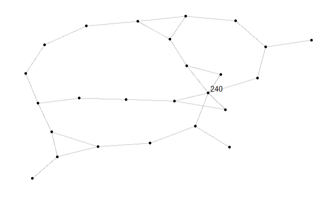

- b

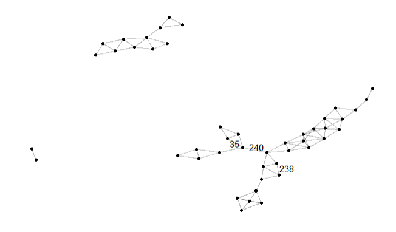

- c

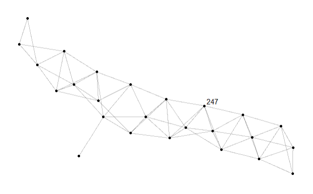

7. Imagine this is a terrorist communication network. They use small community (also called as subgraph) to communicate to avoid suspicion. We are told to find **which node is the most important for spreading information between subgraph**. **Without using any filter and communtiy**, calculate eigenvector, betweenness, closeness, degree centrality and select which pair of nodes that need to be terminated first.
- 66, 104
- 208, 46
- 172, 165
- 46, 28

Goodluck!